Kvinnor och män i Dalarna

# Kvinnor och män i Dalarna

Rapporten är skapad av Samhällsanalys, Region Dalarna  
Senast uppdaterad: 2026-11-17

# Sammanfattning

Jämställdhetspolitikens mål handlar om att säkerställa att kvinnor och män har samma makt att forma samhället och sina egna liv. Det innebär att synliggöra både makt, representation och resursfördelning mellan kvinnor och män, och utvecklingen följs därför med både kvalitativa och kvantitativa mått. Denna rapport ger en kvantitativ bild av nuläget i Dalarna med utgångspunkt i de sex jämställdhetspolitiska delmålen som det övergripande målet är uppdelat i. Rapporten ger även en kommunal och regional fördjupning och är ett komplement till SCB:s skrift *[På tal om kvinnor och män](https://www.scb.se/hitta-statistik/statistik-efter-amne/befolkning-och-levnadsforhallanden/jamstalldhet/jamstalldhetsstatistik/produktrelaterat/rapporter/kvinnor-och-man-2026)[^1]*. De viktigaste trenderna och mönstren i Dalarna visar att:

- Inom politiken har representationen av kvinnor och män på förtroendeposter under de senaste årtiondena jämnats ut. Det råder dock fortfarande stora skillnader på lokal nivå och 5 av Dalarnas 15 kommuner har en övervikt (mer än 60 %) av män i fullmäktige.
- I likhet med riket som helhet har kvinnor i Dalarna en avsevärt lägre medianinkomst än män, även om kvinnors inkomster har ökat i något högre takt än mäns de senaste decennierna.
- Andelen högutbildade ökar bland både kvinnor och män, men bland kvinnor är ökningstakten högre. Idag är nästan dubbelt så många kvinnor som män i Dalarna högutbildade.
- Obalansen mellan tjejers och killars val till gymnasieprogrammen består. Endast 5 program av 19 har en jämn representation av tjejer och killar.
- Föräldrapenningdagarna fördelas betydligt jämnare mellan föräldrarna nu i jämförelse med början av 1990-talet, men fördelningen i Dalarna är fortfarande långt ifrån jämställd.
- Kvinnors ohälsa mätt genom frånvaro från arbetsplatsen är betydligt mer omfattande än mäns. Skillnaden gäller oavsett bransch, och är tydligast när det gäller stressrelaterade symptom.
- Samtidigt som män i genomsnitt har bättre livsvillkor än kvinnor är det också en grupp män som har det relativt sett sämre ställt i form av utanförskap, dålig ekonomi, ohälsa och i högre grad skulder hos Kronofogden. Dessa faktorer leder vanligtvis till en genomsnittligt kortare medellivslängd.
- Den självrapporterade utsattheten för flera brottstyper har minskat över tid, men stora skillnader kvarstår mellan kvinnor och män – särskilt när det gäller sexualbrott och upplevd trygghet. Kvinnor utsätts i betydligt högre grad än män för sexualiserat våld och upplever också en större oro, vilket i sin tur påverkar deras rörelsefrihet och vardagliga val.

# Introduktion

Världsläget synliggör fundamentala utmaningar för demokratiska samhällen, samtidigt som en konstruktiv diskussion om jämställdhet i stort förefaller ha kommit i skymundan i den allmänna debatten. Att sträva efter jämställdhet är trots det en av de mer centrala insatserna för att säkerställa mänskliga rättigheter och att uppnå de 17 målen i Agenda 2030 tillsammans med nationella miljö- och demokratimål, med flera politiskt beslutade mål, för ett demokratiskt välfärdssamhälle.

För Dalarna är de regionala målen manifesterade i den regionala utvecklingsstrategin [Dalastrategin 2030 - Tillsammans för ett hållbart Dalarna](https://www.regiondalarna.se/contentassets/699fddaa79da4978bfe14dd4bead1134/dalastrategin-2030-tillsammans-for-ett-hallbart-dalarna-dec.pdf), med övergripande målsättning om ett sammanhållet Dalarna med goda livsmiljöer där människor skapar delaktighet och engagemang, och bidrar till en hållbar utveckling. Arbete för att nå målen sker i nära samverkan med Länsstyrelsen i Dalarnas län som under mandatperioden har ett par regeringsuppdrag för politikområdet sammanfattade i strategierna [Ett jämställt Dalarna](https://catalog.lansstyrelsen.se/store/26/resource/308), och [Ett Dalarna fritt från våld](https://catalog.lansstyrelsen.se/store/26/resource/266).

Alla offentliga verksamheter i Dalarna så som Region Dalarna, Länsstyrelsen Dalarna, länets kommuner och lärosäte arbetar således på olika sätt aktivt för att verkställa den regionala och nationella jämställdhetpolitiken och respektive organisations särskilt uppsatta mål för jämställdhet. Följande rapport är tänkt att ge en bild av hur jämställdheten utvecklas i Dalarna baserat på den statistik som finns tillgänglig på regional och kommunal nivå. I rapporten diskuteras även läget i relation till nationella trender och utmaningar. Rapporten är strukturerad utifrån de första sex delmålen för jämställdhetspolitiken:

1. En jämn fördelning av makt och inflytande
2. Ekonomisk jämställdhet
3. Jämställd utbildning
4. Jämn fördelning av det obetalda hem - och omsorgsarbetet
5. Jämställd hälsa
6. Mäns våld mot kvinnor ska upphöra
7. Hedersrelaterat våld och förtryck ska upphöra (nytt mål från 2026)

Region Dalarna har tidigare publicerat jämställdhetsanalyser av läget i Dalarna på webben, år 2022, 2023, 2024, samt en fördjupande uppföljning av jämställdhet i länet år 2019 [Kvinnor och män i Dalarna ur ett jämställdhetsperspektiv](https://www.regiondalarna.se/contentassets/d845727dbc9f49c3b7b09a2c60456497/jamstalldhetsrapport.pdf)[^2] som togs fram inom projektet Jämställd regional tillväxt.

Det görs även nationella uppföljningar av jämställdhetspolitiken. För mer information om dessa, klicka på rutan nedan:

**Nationella uppföljningar av jämställdhetspolitiken**

Nationella uppföljningar av hur jämställdhetspolitiken bidrar till målen görs både genom statistik- och policy-analyser. Statistiska uppföljningar görs av bland andra Statistiska centralbyrån (SCB) som vart annat år (sedan 1984) publicerar skriften [På tal om kvinnor och män](https://www.scb.se/hitta-statistik/statistik-efter-amne/befolkning-och-levnadsforhallanden/jamstalldhet/jamstalldhetsstatistik/produktrelaterat/rapporter/kvinnor-och-man-2026/) och vart tionde år (sedan 1990) gör [tidsanvändningsstudier](https://www.scb.se/contentassets/4e98132b0b784a01b6e4762e909a6fa2/le0103_2021a01_br_lebr2202.pdf)[^3], nu senast 2021. Vidare analyseras årligen i regeringens budgetproposition hur den ekonomiska jämställdheten utvecklas, vilket redovisas i [Prop. 2026/27:1 bilaga 3 Ekonomisk jämställdhet](https://www.regeringen.se/contentassets/182eafe7720b42ebbf5b49d918365111/ekonomisk-jamstalldhet/)[^4].

Policy-uppföljningar av jämställdhetspolitiken görs av bland andra Jämställdhetsmyndigheten. Myndigheten har även granskat den regionala politiken ur ett jämställdhetsperspektiv. I rapporten [Regionalpolitik, könsmönster och jämställdhetsambitioner](https://jamstalldhetsmyndigheten.se/media/xkfccjgj/rapport-2022-16-bilaga-1-regionalpolitik-ko-nsmo-nster-och-ja-msta-lldhetsambitioner.pdf)[^5] finns en fördjupning om läget i regionerna. Här påpekas bland annat att det behövs en bättre styrning mot jämställdhetsmålen genom relevanta indikatorer. Mer konkret handlar det bland annat om att följa upp och förebygga ojämställda arbetsvillkor, ojämställda inkomster, kvinnors och mäns psykiska ohälsa och långtidssjukskrivningar, och synliggöra regionala och lokala könsmönster samt intersektionella perspektiv.

# 1 Makt och politik

Det första av de jämställdhetspolitiska delmålen lyder “en jämn fördelning av makt och inflytande”. Detta mäts bland annat genom kvinnors och mäns representation på maktpositioner i politiken och chefspositioner i arbetslivet, både offentlig sektor och näringsliv. Historiskt har män befolkat dessa positioner och kvinnor i undantagsfall. Dessvärre visar nuläget att många traditionella mönster består. Generellt visar siffrorna på att ju högre upp i hierarkin man kommer, desto fler män befolkar positionerna. [Jämställdhetsmyndigheten](https://jamstalldhetsmyndigheten.se/jamstalldhet-i-sverige/delmal-1-jamn-fordelning-av-makt-och-inflytande/) skriver att:

> Näringsliv, högre utbildningar och organisationer med mindre insyn har få kvinnor på höga positioner.

Samtidigt har representationen förbättrats inom både offentlig sektor och inom politiken de senaste decennierna. I följande avsnitt redovisas läget för den politiska representationen samt andelen kvinnor och män på chefspositioner, i relation till utbildningsnivå och inom olika branscher.

## 1.1 Politisk representation

Den politiska sfären har historiskt varit mansdominerad och avsevärt färre kvinnor har haft tunga politiska uppdrag. Diagrammet nedan visar könsfördelningen bland riksdagsledamöter från valet 1973 till 2022. Riksdagens könsfördelning har under den här tidsperioden genomgått en stor förändring och utveckling. Vid riksdagsvalet 1973 var en övervägande majoritet av de folkvalda ledamöterna män. Endast 74 kvinnor återfanns på bänkarna i Riksdagen under den här mandatperioden. 49 år senare är männen fortfarande fler än kvinnorna, men skillnaden mellan könen är bara 27 stycken ledamöter. Den mest jämställda Riksdagen i Sverige var mandatperioden som tog sin början 2006 då antalet kvinnor var 165.

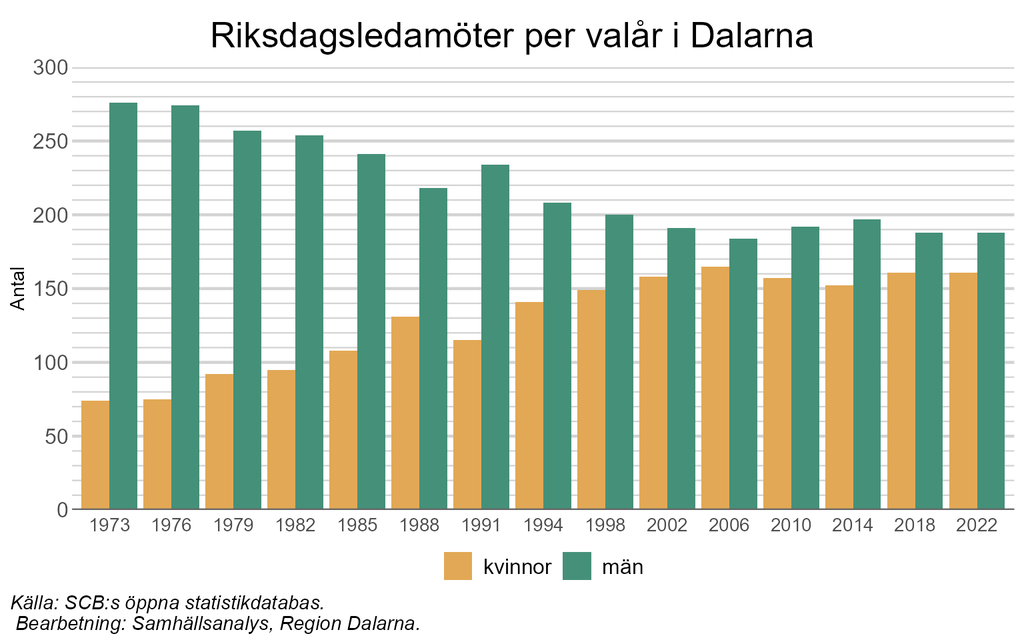

Den positiva trenden om en mer jämställd representation bland de folkvalda på nationell nivå syns även på regional nivå. Vid landstingsvalet (från 2022 regionval) 1982 i Dalarna var antalet ledamöter i fullmäktige övervägande män, medan könsfördelningen vid valet 2014 i princip var helt jämställd med ett nästan jämnt antal män och kvinnor bland folkvalda i fullmäktige. Efter valet 2018 syns däremot återigen en ökning av andelen män i fullmäktige och sedan det senaste valet (2022) sitter 11 fler män än kvinnor i det som nu heter regionfullmäktige.

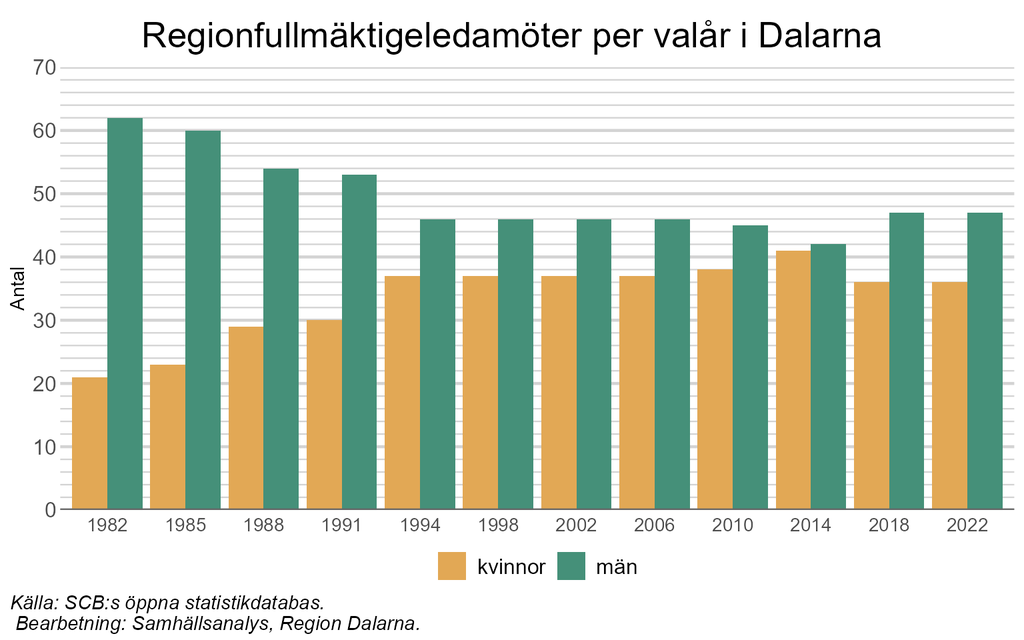

På lokal nivå i Dalarna finns det stora skillnader mellan kommunerna. Efter valet 2022 var Avesta och Smedjebacken de enda kommuner i länet där kvinnorna i fullmäktige översteg antalet män. Borlänge, Gagnef, Mora, Rättvik och Vansbro har istället en majoritet män, dvs mer än 60 procent, bland deras folkvalda ledamöter.

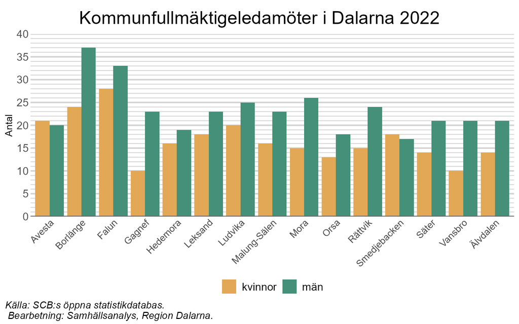

## 1.2 Representation på chefspositioner

Ett annat mått på makt är den ställning individen har på arbetsplatsen och i yrkeslivet. I diagrammet nedan visas andelen chefer av de sysselsatta uppdelade efter utbildningsnivå och kön. I samtliga utbildningsgrupper i Dalarna är en större andel av männen sysselsatta i någon form av chefsposition jämfört med motsvarande grupp kvinnor. Andelen chefer är även tydligt kopplad till en högre utbildningsnivå där högre utbildning är associerad med en högre andel individer i chefspositioner. Bland gruppen män med eftergymnasial utbildning innehar cirka 11 procent någon form av chefsställning. Bland kvinnor med eftergymnasial utbildning är motsvarande siffra ungefär 8 procent.

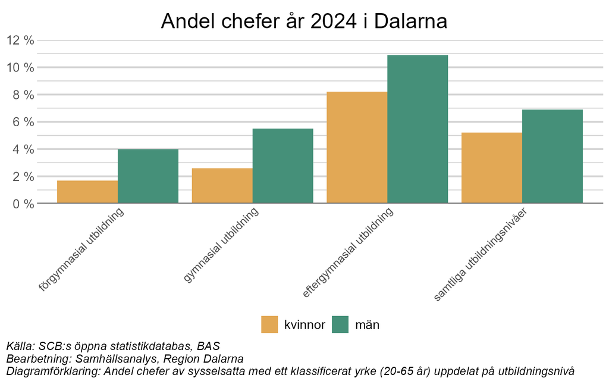

I diagrammet nedan ser vi utveckling över tid. Andelen kvinnor i chefsposition i Dalarna har fördubblats under en tjugoårsperiod, och under samma period är andelen män i chefspositioner mer eller mindre oförändrad. Det betyder att antalet chefspositioner har ökat i antal, och det är kvinnor som befolkat dessa. Totalt sett så gör det att utvecklingen över tid ändå går i en mer jämställd riktning, även om situationen på arbetsmarknaden fortsatt får anses vara ojämställd.

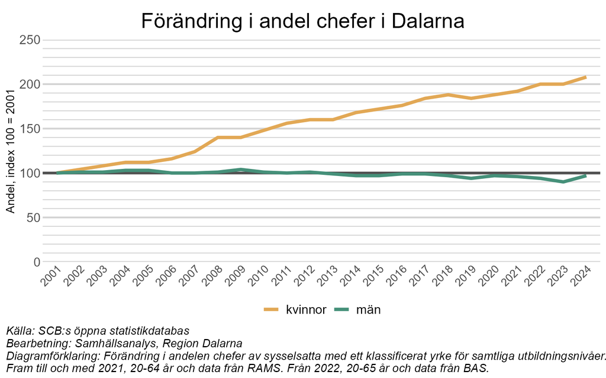

I diagrammet nedan visas över-/underrepresentation av chefer utifrån kön inom olika branscher i Dalarna. Ett värde på 0 indikerar att andelen manliga/kvinnliga chefer är proportionerligt mot andelen anställda män/kvinnor i branschen, medan ett värde över 0 visar på en överrepresentation av män på chefspositionerna, och ett värde under 0 visar på en överrepresentation av kvinnor på chefspositionerna.

En överrepresentation av män på chefspositioner kan antas vara störst i branscher där en tydlig majoritet av de som arbetar är män, såsom bygg, tillverkning och utvinning. Men som synes i diagrammet är dock andelen män på chefspositioner i dessa branscher proportionerlig sett till andelen anställda män. Inom flera andra branscher, däribland stora branscher som handel, hotell och restaurang samt utbildning, är däremot män på chefspositioner överrepresenterade sett till könsfördelningen bland de anställda inom branschen. Samtidigt finns det totalt sett en tydlig trend mot en ökad andel kvinnor på chefspositioner. Den manliga överrepresentationen på chefsnivå har minskat inom samtliga branscher förutom jord- och skogsbruk mellan 2008 och 2022. Inom vård- och omsorgsbranschen har en tydlig överrepresentation av män bytts mot en underrepresentation av män, vilken även gäller inom offentlig förvaltning.

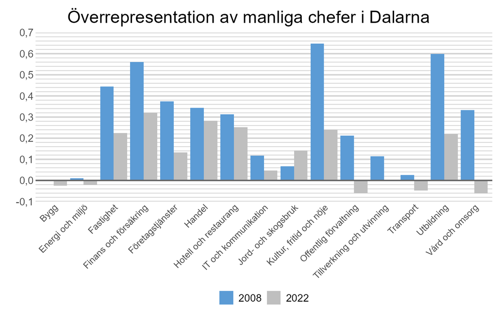

# 2 Ekonomisk jämställdhet

Ekonomisk jämställdhet syftar till att kvinnor och män ska ges samma möjligheter och villkor i fråga om betalt arbete för att säkerställa ekonomisk självständighet livet ut. Målet utgår således ifrån ett livscykelperspektiv och understryker betydelsen av att det avlönade arbetet ska ge ekonomisk trygghet och självständighet även under pensionsåren.

Ekonomisk jämställdhet analyseras genom flera olika inkomstflöden och variabler. En central förutsättning för en inkomst och egen försörjning är anknytning till och förutsättningar på arbetsmarknaden, därför redogörs här även för sysselsättningsgrad och arbetslöshet, tillsammans med etableringstid på arbetsmarknaden för invandrade, bidragsmottagare, samt hur stor andel av befolkningen som har skulder till Kronofogden.

Inkomst av arbete utgör merparten av en individs försörjning, men både lönenivå och huruvida personen arbetar hel- eller deltid påverkar inkomsten och sedemera pensionen. Därtill finns kapitalinkomster och offentliga bidrag så som exempelvis sjukpenning, föräldrapenning och bostadsbidrag, som gör att ett centralt mått för att fånga en individs ekonomiska standard är beräkningen av den disponibla inkomsten. Disponibel inkomst innebär den summa pengar som ett hushåll eller en person har att röra sig med efter att alla ekonomiska inkomster är sammanräknade (lön, avkastning, bidrag etc.) och skatter och avgifter är betalda.

Det finns många faktorer som bidrar till ojämställdhet på arbetsmarknaden och som sedan medför en ojämställd livsinkomst, men familjebildningen är den faktor som i högst grad bidrar till ojämställd ekonomi. Ett exempel med nationella siffror som synliggör hur familjelivet skapar skillnader är att gapet i disponibel inkomst mellan kvinnor och män är som störst för sammanboende, 35 procent, när det yngsta barnet är 0–3 år [(Regeringen, 2022)](https://www.regeringen.se/contentassets/46945970585240a4a5bfd9a0f75ecf3d/ekonomisk-jamstalldhet.pdf)[^6].

Men, även löneskillnader mellan könen inverkar på livsinkomsten och börjar i praktiken i relativt ung ålder. Redan vid 29 års ålder har män i genomsnitt 20 procent högre medianinkomst än kvinnor, nationellt. En del av skillnaden kan förklaras av skillnader i utbildningsval, då fler kvinnor väljer att studera och därmed kommer ut senare i arbetslivet. Trots en högre utbildningsnivå kvarstår dock gapet i lön mellan könen [(Jämställdhetsmyndigheten, 2025)](https://jamstalldhetsmyndigheten.se/media/llefhgq1/kunskapssammanst%C3%A4llning-ungas-ekonomi-2025-1.pdf)[^7].

På nationell nivå har SCB jämfört den standardvägda lönen, dvs. lönen när hänsyn tas till bland annat ålder och utbildningsnivå, för att synliggöra om det kan finnas en diskrimineringsaspekt i eventuella löneskillnader. Slutsatsen blev att kvinnors standardvägda lön är ungefär 95 procent av männens standardvägda lön, det vill säga det finns en oförklarad löneskillnad mellan kvinnor och män [(SCB)](https://www.statistikdatabasen.scb.se/pxweb/sv/ssd/START__AM__AM0110__AM0110B/LonStandVagdYrkA/).

## 2.1 Inkomst och disponibel inkomst

En egen inkomst är en av förutsättningarna för ett ekonomiskt självständigt liv. Livsinkomsten påverkar även vilken pension personen kommer att få vid pensionering.

För kvinnor och män i Dalarna i arbetsför ålder (20-64 år) är inkomstskillnaderna relativt stora och har hållit i sig över tid. Medianinkomsten för en man i Dalarna var 2024 cirka 427 tusen kronor före skatt, medan en kvinna hade en medianinkomst på ungefär 355 tusen kronor. I den andra figuren nedan syns även en positiv utveckling i form av att den relativa skillnaden i inkomst mellan könen har minskat sedan millennieskiftet. Diagrammet visar att kvinnors medianinkomst har ökat med ungefär 120 procent sedan millennieskiftet, medan mäns har ökat med ungefär 100 procent. Det är dock viktigt att notera att figurerna nedan endast redovisar kvinnors och mäns skilda ekonomiska förutsättningar, medan det kan finnas flera förklaringar till skillnaden. En faktor är att kvinnor i högre grad arbetar deltid, och därför kan ha en lägre årsinkomst. Men även yrke, bransch och utbildningsinriktning kan förklara en del av skillnaden.

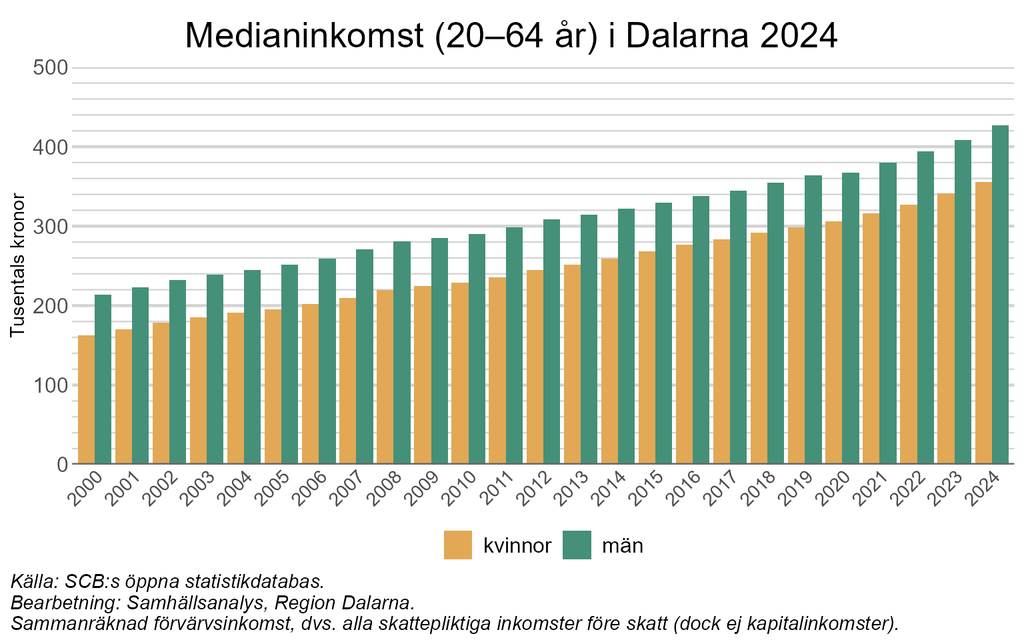

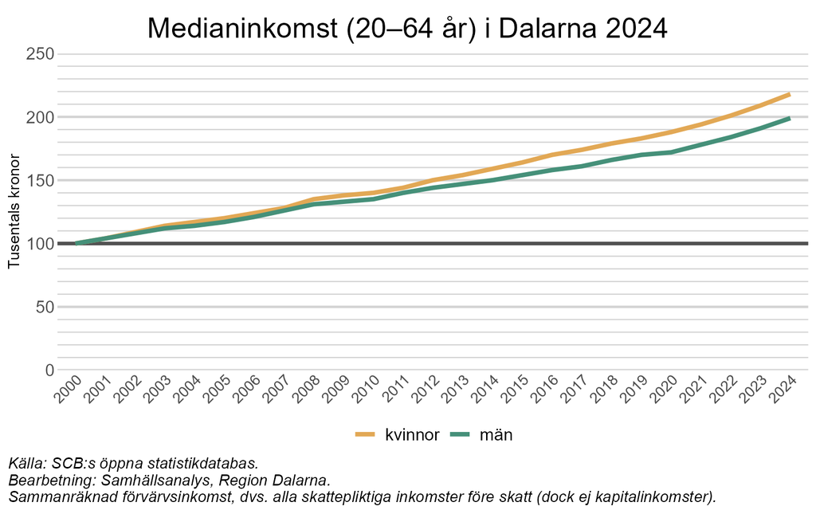

I samtliga av Dalarnas kommuner har männen högre medianinkomst än kvinnorna. Skillnaderna mellan kommunerna är relativt små. Medianinkomsten är högst i Smedjebacken för män och i Falun för kvinnor. Medianinkomsten är lägst i Orsa för män och i Vansbro för kvinnor.

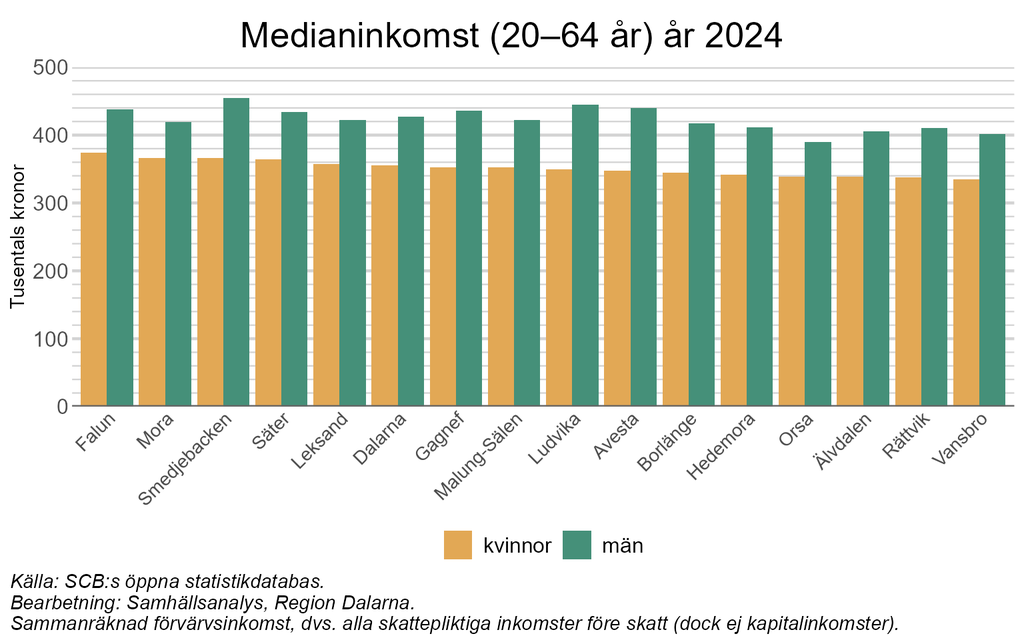

Personer 65 år och äldre har en lägre medianinkomsten än personer i arbetsför ålder (20-64 år). I Dalarna var medianinkomsten år 2024 för män 65 år och äldre 288 tusen kronor före skatt, medan en kvinna i samma åldersgrupp hade en medianinkomst på 230 tusen kronor. Att inkomsterna är lägre för personer 65 år och äldre är rimligt eftersom många i den åldern har gått i pension och då har lägre inkomster än de hade när de förvärvsarbetade.

Men det finns även numera många som fortsätter att arbeta hel- eller deltid efter ordinarie pensionsålder, så kallade jobbonärer, dessa har relativt god ekonomi. De som har det sämst ställt efter pensionering är kvinnor som inte fortsätter att arbeta.

I den andra figuren nedan syns dock att den relativa skillnaden i inkomst mellan könen har minskat mer sedan millennieskiftet för personer äldre än 65 år, jämfört med de i arbetsför ålder (20-64 år). Diagrammet visar att kvinnors medianinkomst har ökat med ungefär 170 procent medan mäns har ökat med knappt 100 procent.

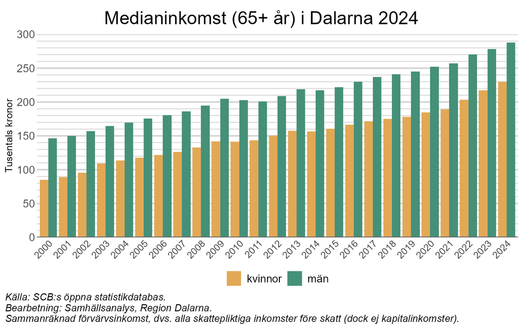

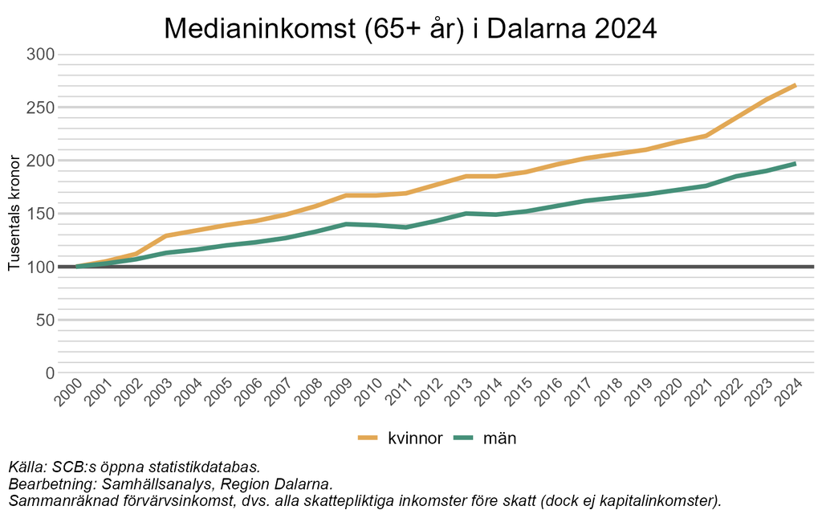

Utöver inkomster är det även relevant att jämföra den disponibla inkomsten, dvs. summan av alla inkomster och transfereringar (exempelvis bostadsbidrag och barnbidrag) efter avdragen slutlig skatt. I figuren nedan är det tydligt att den disponibla inkomsten varierar mellan olika grupper. En generell trend för alla grupper är att den disponibla inkomsten, utan att justera för inflation, har ökat mellan 2011 och 2024

Det är tydligt att sammanboende, med eller utan barn, har en högre disponibel inkomst än ensamstående. Sammanboende med barn har också en högre disponibel inkomst än sammanboende utan barn. På andra sidan av skalan återfinns gruppen ensamstående kvinnor utan barn som har lägst disponibel inkomst. Diagrammet visar också på att det finns tydliga skillnader mellan könen. Bland ensamstående har män, med eller utan barn, högre disponibel inkomst än kvinnor i motsvarande grupp.

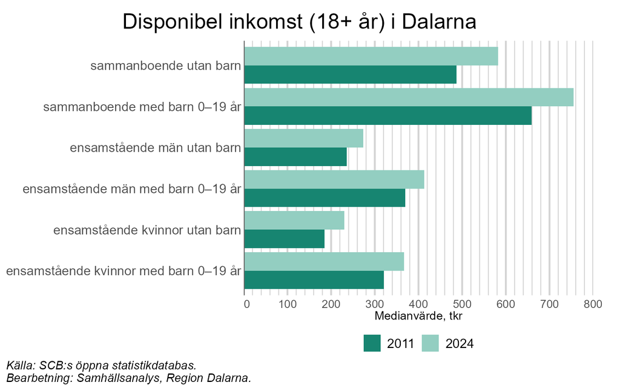

## 2.2 Sysselsättning och arbetslöshet

Sysselsättningsgraden, det vill säga i vilken utsträckning människor i arbetsför ålder (20-64 år) arbetar, skiljer sig inte märkbart åt mellan könen bland inrikes födda som ses i det vänstra diagrammet nedan. Sverige ligger långt fram i en internationell jämförelse när det gäller att ge kvinnor och män likvärdiga möjligheter att yrkesarbeta, och det återspeglas i sysselsättningsgraden som för båda könen är ungefär lika hög, 86,3 procent för kvinnor och 86 procent för män. Variationen i sysselsättningsgrad mellan länen är därför också relativt liten.

Däremot skiljer sig sysselsättningsgraden åt mellan inrikes och utrikes födda. För utrikes födda (det högra diagrammet nedan) är sysselsättningsgraden lägre än sysselsättningsgraden för inrikes födda i samtliga svenska län. Det finns även skillnader mellan kvinnor och män.

Utrikes födda män har en högre sysselsättningsgrad än utrikes födda kvinnor i samtliga län. I Dalarna var sysselsättningsgraden bland utrikes födda män 76 procent, vilket är cirka 8 procentenheter mer än för utrikes födda kvinnor i Dalarna.

Något att ta hänsyn till när man analyserar sysselsättningsgrad och arbetslöshet bland utrikes födda är hur lång tid individen har varit i Sverige. Vistelsetid i Sverige har ett starkt samband med sysselsättningsgrad och arbetslöshet och därmed kommer andelen nyligen invandrade i gruppen utrikes födda att påverka nivån på dessa variabler.

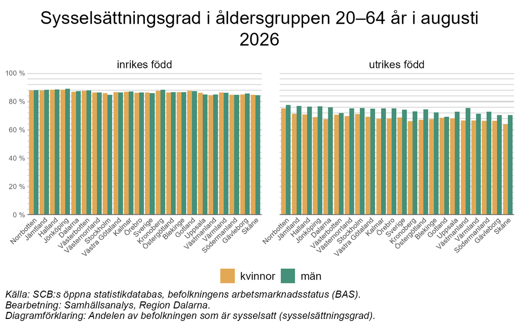

Sysselsättningsgraden i respektive kommun i Dalarna visar ett liknande mönster som länen på nationell nivå. Gruppen inrikes födda har en högre sysselsättningsgrad i samtliga kommuner i Dalarna jämfört med utrikes födda. Även här är sysselsättningsgraden för inrikes födda kvinnor och män ungefär lika hög. För utrikes födda är det däremot stora skillnader mellan kvinnor och män, också mellan olika kommuner. I linje med den nationella bilden är sysselsättningsgraden högre för gruppen utrikes födda män i jämförelse med utrikes födda kvinnor, i de flesta kommuner. Sysselsättningsgraden för utrikes födda män skiljer sig dock åt mellan kommuner där den högsta sysselsättningsgraden finns i Gagnef (83 procent) och den lägsta i Älvdalen (67,1 procent).

Orsa har den högsta sysselsättningsgraden för gruppen utrikes födda kvinnor i Dalarna, 76 procent, och ligger klart över genomsnittet för länet. Samtidigt är sysselsättningsgraden i Ludvika kommun bland utrikes födda kvinnor bara 61,9 procent.

Värt att notera är att en del av skillnaden i utrikes föddas sysselsättningsgrad mellan kommunerna sannolikt kan förklaras av skillnader vilka kommuner som tog emot flest personer under åren runt 2015 då invandringen till Sverige var mycket stor. Exempelvis var Avesta, Ludvika och Hedemora de tre kommuner som tog emot flest invandrare i förhållande till folkmängd under 2015-2017. Detta förefaller i första hand gälla för utrikes födda kvinnor, då framförallt Ludvika har relativt hög sysselsättningsgrad för utrikes födda män, medan den är klart lägre för utrikes födda kvinnor. I Ludvika är skillnaden mellan könen i sysselsättningsgrad ungefär 18 procentenheter, vilket är den största skillnaden i länet.

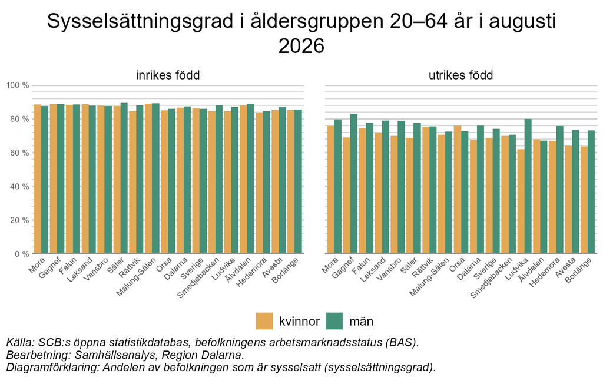

Bilden av arbetsmarknaden kompletteras genom att titta på arbetslösheten som visar hur många av de aktivt arbetssökande som inte har ett arbete. En jämförelse av arbetslösheten bland utrikes respektive inrikes födda åskådliggör ett antal viktiga skillnader.

Arbetslösheten är generellt högre för utrikes födda än för inrikes födda. Arbetslösheten för inrikes födda i Dalarna var i augusti 2026 lägre än rikets, 2 procent bland kvinnor och 2,8 procent bland män (se diagrammet nedan).

Arbetslösheten bland utrikes födda är däremot betydligt högre i samtliga av Sveriges län. I Dalarna är skillnaden i arbetslöshet mellan utrikes och inrikes födda knappt 11 procentenheter för kvinnor och drygt 6 procentenheter för män. Vidare är arbetslösheten bland gruppen utrikes födda kvinnor klart högre än i gruppen utrikes födda män i samtliga av Sveriges län.

I figuren nedan framgår också att det finns avsevärda skillnader mellan länen. Norrbotten har den lägsta arbetslösheten för såväl utrikes födda män som kvinnor med 4,6 respektive 5,8 procent, medan Gävleborg har den högsta arbetslösheten med 13,1 procent för män och 17,8 procent för kvinnor. Dalarnas arbetslöshet bland utrikes födda är ungefär som riksgenomsnittet.

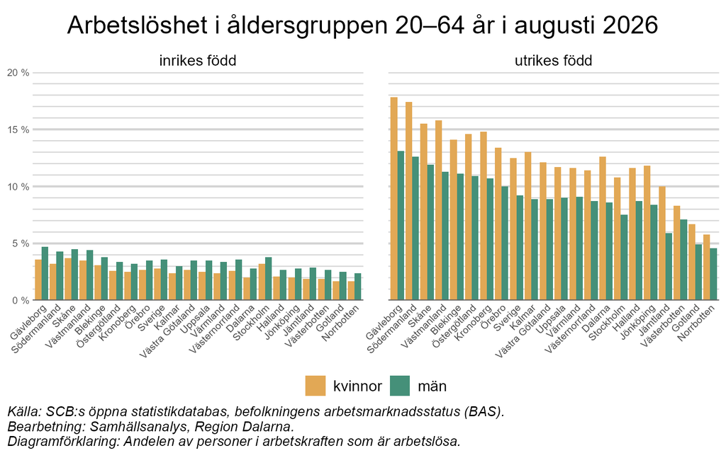

Precis som var fallet med sysselsättningsgrad tidigare, så uppvisar Dalarnas kommuner ett liknande mönster som på nationell nivå. Bland inrikes födda är arbetslösheten låg och något fler män än kvinnor är arbetslösa. Arbetslösheten för inrikes födda är högst i Hedemora för både kvinnor och män, 2,9 procent för kvinnor respektive 3,8 procent för män.

Lägst arbetslöshet för inrikes födda kvinnor återfinns i Mora med 1,3 procent, medan den lägsta arbetslösheten för inrikes födda män finns i Malung-Sälen med 1,8 procent.

I de flesta kommuner är arbetslösheten bland utrikes födda avsevärt mycket högre för både kvinnor och män än för inrikes födda. Genomsnittet i Dalarnas län ligger på 12,6 procent bland utrikes födda kvinnor och 8,6 procent bland utrikes födda män. Arbetslösheten för utrikes födda är högst i Avesta för både kvinnor och män, 17,9 procent för kvinnor respektive 12 procent för män.

Arbetslösheten för utrikes födda är lägst i Rättvik för både kvinnor och män, 2,3 procent för kvinnor respektive 4,4 procent för män. För kvinnor är detta mer eller mindre i linje med arbetslösheten för inrikes födda (2,2 procent).

Det är återigen värt att notera att de skillnader i arbetslöshet som diskuterades i stycket om sysselsättningsgrad ovan sannolikt delvis kan förklaras av skillnader i antalet personer och hur nära i tid som de invandrat till olika kommuner.

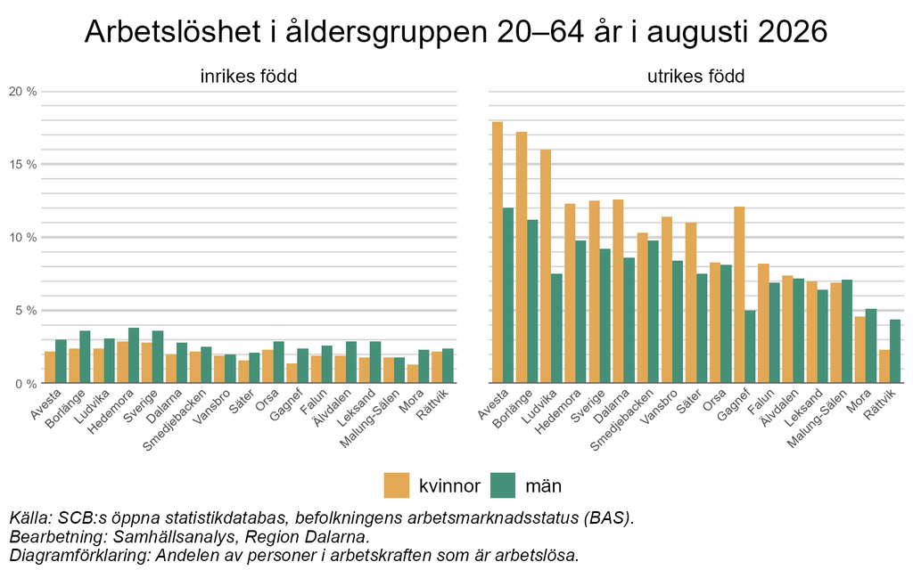

Arbetslösheten i Dalarna har utvecklats olika för inrikes och utrikes födda. Bland inrikes födda syns en tydlig övergripande nedgång från toppnivåerna 2010. Under pandemiåret 2020 bröts utvecklingen tillfälligt när arbetslösheten ökade för både kvinnor och män.

Bland utrikes födda kan två övergripande faser urskiljas. Mellan 2008 och 2017 ökade arbetslösheten kraftigt och nådde 2017 cirka 30 procent bland kvinnor och 37 procent bland män. Ökningen sammanföll med en period av stor flyktinginvandring till Sverige, särskilt omkring 2015–2016, men diagrammet visar inte i sig vilka faktorer som förklarar utvecklingen. Under perioden 2008–2018 var arbetslösheten genomgående högre bland utrikes födda män än bland utrikes födda kvinnor, med särskilt stora skillnader under 2015–2017.

Sedan toppnivåerna 2017 har arbetslösheten bland utrikes födda minskat kraftigt, även om nedgången inte varit helt obruten. Skillnaden mellan könen har samtidigt vänt. I den senaste redovisade perioden, 2026, var arbetslösheten ungefär 15 procent bland utrikes födda kvinnor och ungefär 12 procent bland utrikes födda män.

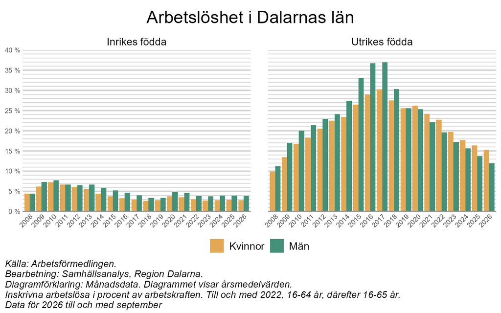

Hur långt från arbetsmarknaden en person befinner sig påverkas bland annat av hur länge personen har varit utan arbete. Långa perioder av arbetslöshet kan göra det svårare att återvända till arbetsmarknaden, exempelvis genom att kunskaper, erfarenheter och kontakter blir mindre aktuella. Här räknas personer som långtidsarbetslösa om de under minst sex månader har varit inskrivna som öppet arbetslösa eller deltagit i ett program med aktivitetsstöd.

År 2010 var 3,2 procent av kvinnorna och 3,3 procent av männen i Dalarna i åldern 25–64 år långtidsarbetslösa. Under 2010-talet varierade utvecklingen för både kvinnor och män. Bland kvinnor minskade andelen fram till 2014 och ökade därefter till 2017. Bland män var uppgången under mitten av 2010-talet tydligare, och under större delen av perioden var långtidsarbetslösheten högre bland män än bland kvinnor.

I samband med pandemin ökade långtidsarbetslösheten för båda könen och nådde sin högsta nivå 2021, då andelen var 3,7 procent bland kvinnor och 4,0 procent bland män. Därefter har långtidsarbetslösheten minskat varje år. År 2025 var andelen cirka 2,7 procent för både kvinnor och män. Från och med 2023 omfattar statistiken även 65-åringar.

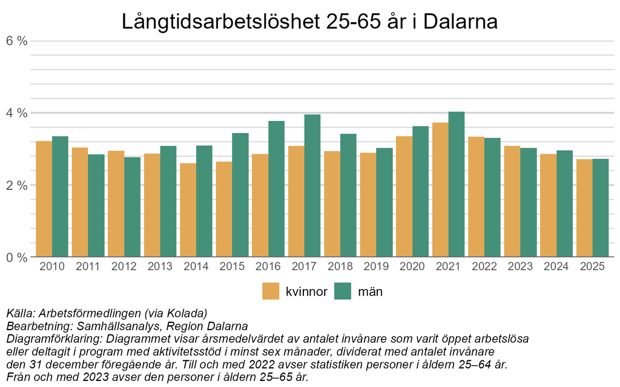

## 2.3 Arbetsmarknadsetablering för invandrade

Som diskuterats tidigare är sysselsättningsgraden lägre bland utrikes födda generellt, och för invandrade kvinnor tar det betydligt längre tid än för invandrade män att etablera sig på arbetsmarknaden. För utrikesfödda kvinnor som befunnit sig i Sverige i upp till 2 år (0-1 år i grafen nedan) är det bara ungefär 34 procent i arbetsför ålder (20-65 år) som arbetar. För motsvarande grupp av män är ungefär 63 procent i arbete inom 2 år. Över tid tenderar ändå etableringsgraden att öka avsevärt och efter mer än tio år i Sverige är det över 70 procent av invandrade såväl män som kvinnor som arbetar.

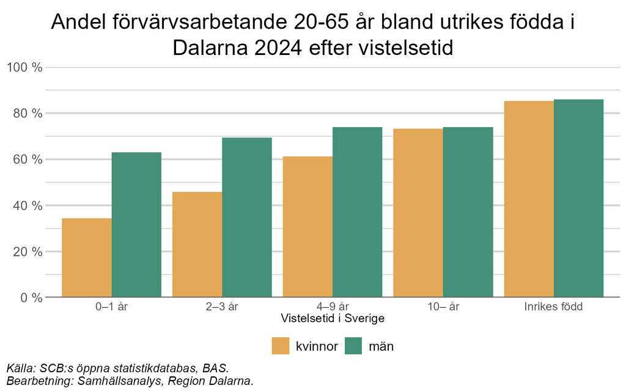

Hur snabbt en invandrad person etablerar sig på arbetsmarknaden har förändrats avsevärt över tid, vilket åskådliggörs i diagrammet nedan. Från början av 2000-talet fram till mitten av 2010-talet låg etableringstiden relativt stabil, där ungefär 20 procent av de 20-64 åringar som varit i Sverige i upp till 2 år (0-1 år i figuren nedan) förvärvsarbetade och ungefär 50-60 procent av de 20-64 åringar som varit i Sverige mellan 4 och 10 år (4-9 år i figuren nedan) förvärvsarbetade. Efter den stora flyktinginvandringen i mitten av 2010-talet verkar dock någonting ha hänt och framförallt personer med kort vistelsetid (upp till 2 år) kommer i arbete betydligt snabbare. Mellan 2015 och 2024 ökade andelen förvärvsarbetande av de 20-64 åringar som varit i Sverige i upp till 2 år (0-1 år i figuren nedan) från ungefär 16 procent till cirka 47 procent, en remarkabel förbättring. Under samma tidsperiod har även arbetslösheten för gruppen utrikes födda minskat betydligt, vilket illustrerats i ett tidigare diagram. Värt att notera är att det i diagrammet nedan är andelen förvärvsarbetande i åldersgruppen 20-64 år som redovisas mellan 1997 och 2021, medan det är andelen förvärvsarbetande i åldergruppen 20-65 år som redovisas åren därefter.

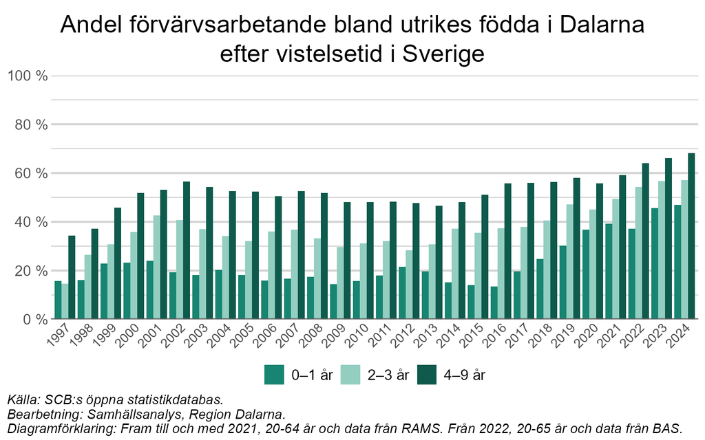

Skillnaden mellan utrikes födda kvinnor och utrikes födda män kan bland annat förklaras med att kvinnor som invandrat från ett utomeuropeiskt land i majoriteten av fallen har gjort det som anhörig, antingen till en person med svenskt medborgarskap eller till en person med permanent uppehållstillstånd. Att vara anhörig till arbetskraftsinvandrare är även vanligt förekommande. Givet dessa skäl för invandring är det vanligt att kvinnor invandrar med små barn eller har ett högt barnafödande de första åren i landet. Det har visat sig att kvinnorna sedan tar ett betydligt större omsorgsansvar för barn än barnens fäder, vilket bidrar till att deras inträde på arbetsmarknaden sker betydligt senare än för män i motsvarande situation. Exempelvis är användningen av föräldrapenning mycket ojämställd bland nyligen invandrade föräldrar. Se exempelvis [Expertgruppen för studier i offentlig ekonomi (2021)](https://eso.expertgrupp.se/wp-content/uploads/2020/03/ESO-2021_7_forsorjning-med-fordrojning_webb.pdf)[^8] och [Jämställdhetsmyndigheten (2022)](https://jamstalldhetsmyndigheten.se/media/s5wdbimq/rapport-sta-rkta-mo-jligheter-genom-samverkan.pdf)[^9].

Att vara anhöriginvandrare sätter också kvinnan i fråga i en särskild beroendeställning till sin respektive anhörige i jämförelse med om hon invandrat/flytt på egna premisser. Detta i kombination med ofta låg utbildning och brist på arbetslivserfarenhet från hemlandet blir också hinder för att delta i integrationsinsatser, utbildning och arbetssökande. Se exempelvis [Expertgruppen för studier i offentlig ekonomi (2021)](https://eso.expertgrupp.se/wp-content/uploads/2020/03/ESO-2021_7_forsorjning-med-fordrojning_webb.pdf) och [Regeringen (2023)](https://www.regeringen.se/contentassets/aaae962745b74fa4abc01f7926bb5adc/sou-2023_24_pdf-a_webb.pdf)[^10].

Regeringen har sedan år 2023 satt fokus på insatser som ska få utrikes födda kvinnor i arbete snabbare. Bland annat har länsstyrelserna ett regionalt uppdrag med detta mål.

För de med lägst utbildningsnivå (förgymnasialt utbildade) är relativt få etablerade på arbetsmarknaden. I den gruppen arbetar bara ungefär 18 procent av de utrikesfödda kvinnor, och cirka 39 procent av de utrikesfödda männen, inom 2 år efter att de kommit till Sverige. Andelen etablerade ökar sedan med vistelsetiden, men är på klart lägre nivåer än för grupper med högre utbildningsvivåer. Även bland inrikes födda är det en klart lägre andel med förgymnasial utbildning som är etablerade på arbetsmarknaden.

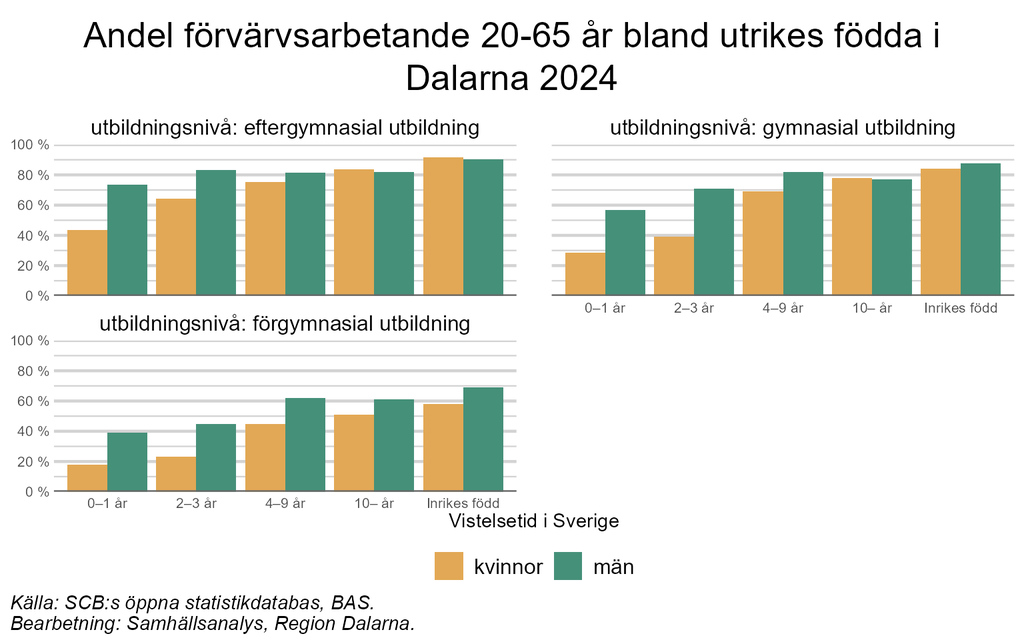

## 2.4 Välfärdsbidragstagare

Samtidigt som fler kvinnor än män mottar transfereringar i form av exempelvis föräldrapenning går andra typer av bidrag i högre utsträckning till män som grupp. Ett sätt att få en bra bild över helheten av sociala ersättningar och bidrag är att analysera helårsekvivalenter. Helårsekvivalenter beskriver hur många personer som under ett år försörjs helt genom sociala ersättningar och bidrag. Måttet räknas i helårspersoner, vilket innebär att flera individer med delårsvisa ersättningar kan motsvara en helårsekvivalent. Syftet är att göra olika ersättningssystem och inte minst det sammantagna bidragstagandet jämförbara över tid och mellan grupper.

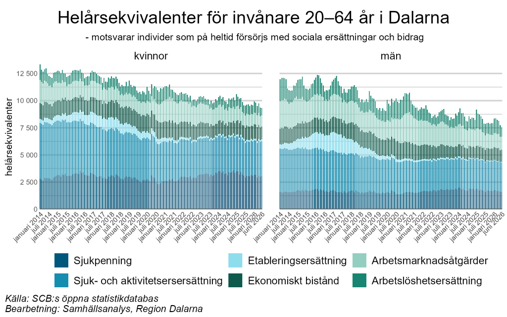

Bidragstagandet ligger på historiskt låga nivåer såväl i Sverige som i Dalarna, både bland kvinnor och män men nivåerna ligger överlag högre bland kvinnor. För kvinnor dominerar sjukpenning samt sjuk- och aktivitetsersättning, som tillsammans står för en större del av försörjningen än hos män. Män har i stället en något större andel ersättning kopplad till arbetslöshet och arbetsmarknadspolitiska program.

## 2.5 Skulder hos Kronofogden

Ytterligare en aspekt som speglar ekonomiska livsvillkor är individers skulder hos Kronofogden, något som både är bekymmer för individen och orsakar stora kostnader för samhället. I det första diagrammet nedan redovisas antalet personer i Dalarna som har skulder under indrivning hos Kronofogden. Två trender är tydliga.

Sedan 2010 har antalet med skulder hos Kronofogden minskat från ungefär 10 300 personer till cirka 9 300 i Dalarnas län. Av dessa är ungefär 61 procent män och 39 procent kvinnor, en fördelning som inte har förändrats över tid. Det är således avsevärt fler män än kvinnor i länet som har skulder hos Kronofogden. Värt att notera är dock att antalet har börjat öka på senare år, vilket kan vara en effekt av högre bolåneräntor och ökad inflation, något som bland annat fått till följd att matpriserna stigit avsevärt [(SVT)](https://www.svt.se/nyheter/ekonomi/nara-tre-ar-med-hog-inflation-sa-dyr-blev-maten).

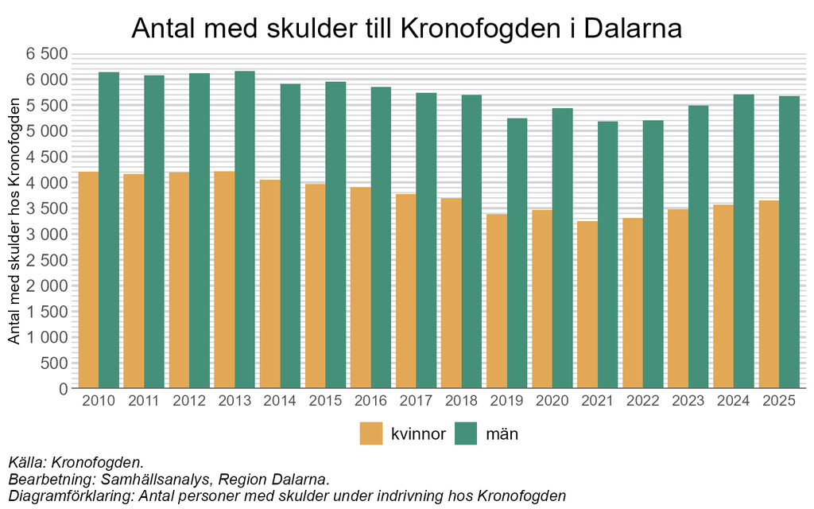

Som andel av befolkningen i Dalarna år 2025 utgör kvinnor med skulder hos Kronofogden 3,2 procent och män 4,9 procent. Medianskulden var för kvinnor knappt 67 000 kr och för män knappt 92 000 kr [(Kronofogden)](https://kronofogden.se/om-kronofogden/statistik/statistik-om-antal-skuldsatta).

Störst andel skuldsatta finns i åldersintervallet 26-34 år, år 2025 var 7,5 procent av männen och 5 procent av kvinnorna i Dalarna i denna åldersgrupp skuldsatta.

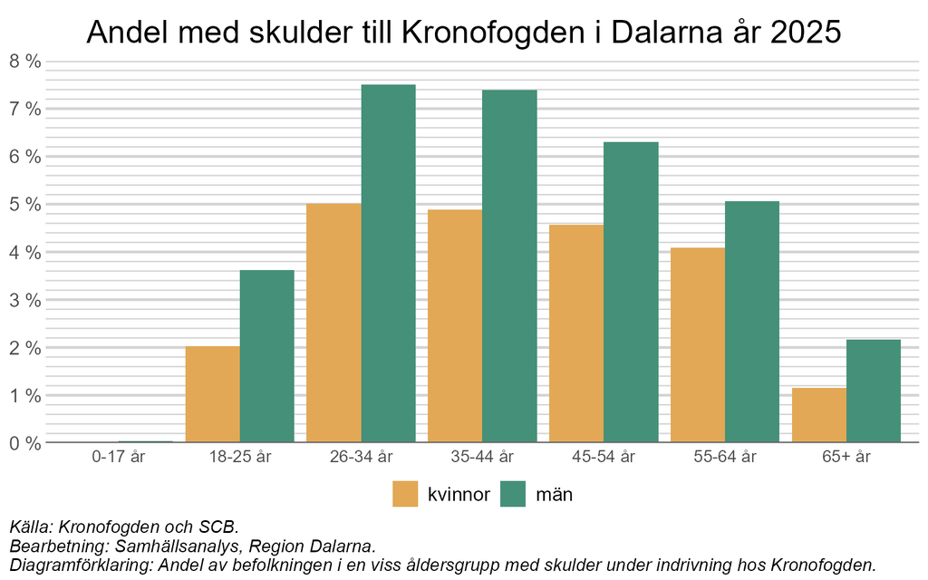

I diagrammet nedan redovisas antalet långsiktigt skuldsatta i Dalarna, vilket betyder individer som under minst 20 års tid har haft skulder till Kronofogden. Även här finns det betydligt fler män än kvinnor till antalet. Åren 2013 - 2016 var en period med ett större antal skuldsatta i båda grupperna, men därefter har antalet minskat bland både kvinnor och män. Mätt över tidsperioden 2010 - 2025 har antalet män minskat med 16 procent medan antalet kvinnor istället har ökat med 18 procent.

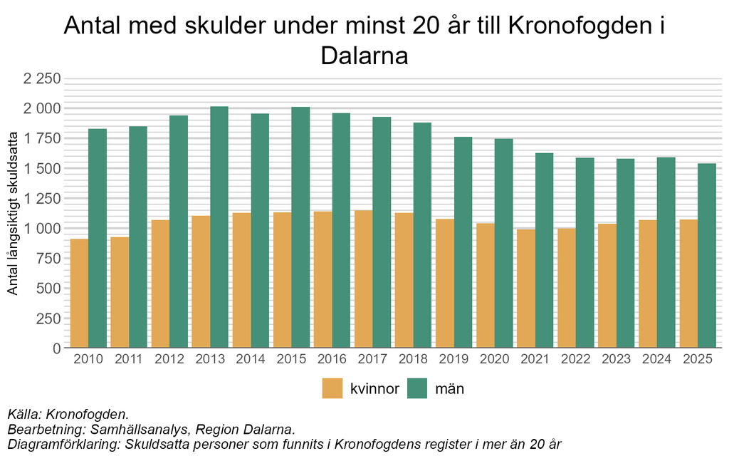

# 3 Utbildning och yrkesliv

Det jämställdhetspolitiska delmålet för utbildningsområdet innebär att kvinnor och män, tjejer och killar, ska ha samma möjligheter och villkor när det gäller utbildning, studieval och personlig utveckling.

Både kvinnor och män vidareutbildar sig efter gymnasiet i högre utsträckning idag än föregående generationer, men betydligt fler kvinnor än män studerar vid universitet och högskola. Att skillnaderna i vidareutbildning ökar mellan könen är negativt för samhällsutvecklingen, då det riskerar att medföra att olika former av könssegregerade miljöer skapas eller upprätthålls. Det medför även skilda förutsättningar på arbetsmarknaden mellan gruppen kvinnor och gruppen män. Eftergymnasial utbildning ger vanligtvis större chans till arbete och möjlighet till högre inkomst.

## 3.1 Utbildningsnivåer

De senaste decennierna har utbildningsnivån bland befolkningen i Dalarna ökat generellt och särskilt andelen med högre utbildning. I mitten av 1980-talet hade bara drygt sju procent av befolkningen en högre utbildning. År 2025 hade den andelen ökat till ungefär 32 procent för kvinnor och ca 17 procent för män. Anmärkningsvärt är dock att skillnaden i utbildningsnivå mellan könen har ökat avsevärt genom åren. I mitten av 1980-talet var andelen högutbildade ungefär lika stor bland kvinnor och män, men 2025 var nästan dubbelt så stor andel kvinnor som män högutbildade i Dalarna.

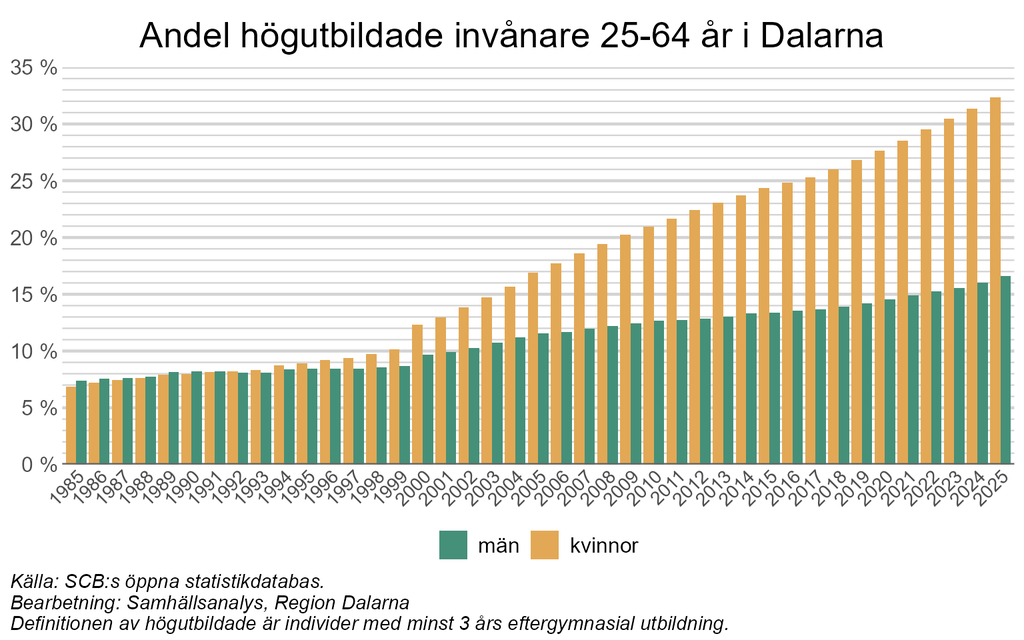

I nationell jämförelse har Dalarna en relativt låg andel personer med högre utbildning. Andelen kvinnor i Dalarna med en högre utbildning om minst 3 år 2025 är ungefär 32 procent och motsvarande siffra för män i länet är cirka 17 procent. Detta utfall placerar Dalarna sämst i landet tillsammans med Gävleborgs, Kalmars och Södermanlands län som har liknande låga siffror.

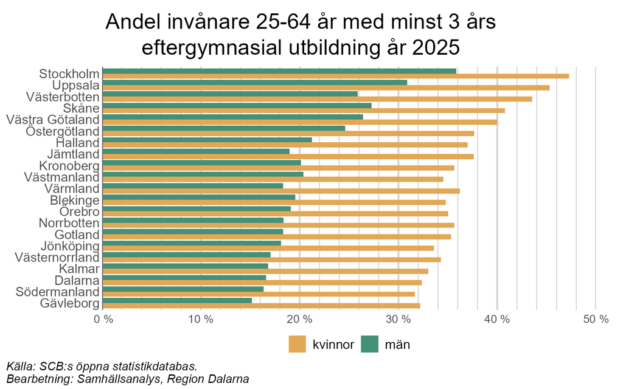

Generellt tenderar regioner med större urbana center att både ha en yngre och en mer välutbildad befolkning jämfört med mer glest befolkade län som Dalarna. Skillnaden är störst bland män, där andelen högutbildade män i Stockholms län är mer än dubbelt så hög som motsvarande andel i Dalarnas län.

En strukturell faktor som kan bidra till könsskillnaden i utbildningsnivå är att många yrken inom kvinnodominerade sektorer så som utbildning och vård kräver högskoleutbildning, exempelvis läraryrket och sjuksköterskeyrket. Dessa yrken utgör också en stor andel av arbetstillfällena på arbetsmarknaden.

Utbildningsnivån inom åldersgruppen 25-64 år i Dalarna år 2025 enligt figuren nedan visar på stora skillnader mellan könen. En betydligt större andel kvinnor i länet har en högre utbildning i jämförelse med andelen män med högre utbildning. Bland kvinnor i Dalarna är den vanligaste, med 32 procent, utbildningsnivån “eftergymnasial utbildning, 3 år eller mer”. Motsvarande andel bland män i Dalarna är 17 procent. Bland män i Dalarna är i stället den vanligast förekommande utbildningskategorin “gymnasial utbildning, 3 år”. Ungefär 33 procent av männen i Dalarna återfinns inom denna kategori.

Räknas alla typer av eftergymnasial utbildning samman är det totalt 47 procent av kvinnorna i Dalarna som har någon form av eftergymnasial utbildning och bland män i länet är motsvarande siffra cirka 30 procent.

Även inom utbildningsnivån gymnasieutbildning om högst 2 år är en större andel män än kvinnor, 23 procent av männen har en gymnasieutbildning om högst 2 år, medan 16 procent av kvinnorna har en gymnasieutbildning om högst 2 år.

Sammantaget innebär detta att ungefär 56 procent av alla män i Dalarna har en gymnasieutbildning som högsta utbildning. Bland kvinnor är motsvarande andel i Dalarna 43 procent.

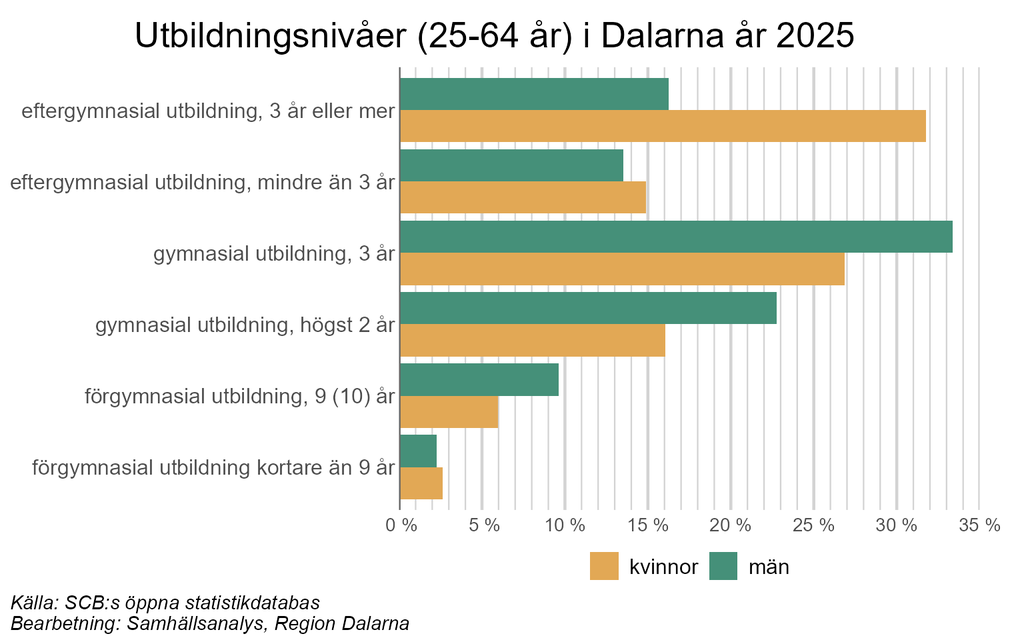

## 3.2 Gymnasieval och avklarad examen

En utmaning för länet är den obalans som råder i antalet antagna killar och tjejer till gymnasieprogrammen i Dalarna. Av totalt 19 gymnasieprogram i länet kan endast 5 sägas vara jämställda, dvs. de har en könsfördelning där andelen antagna är mellan 40 och 60 procent för både killar och tjejer. De program som har en jämställd representation vid antagningen är ekonomiprogrammet, international baccalaurate, introduktionsprogram, naturvetenskapsprogrammet och restaurang- och livsmedelsprogrammet. 6 program har en övervikt av killar, där el- och energiprogrammet har den största obalansen. Resterande 8 program har en övervikt av tjejer, där vård- och omsorgsprogrammet är det mest obalanserade programmet.

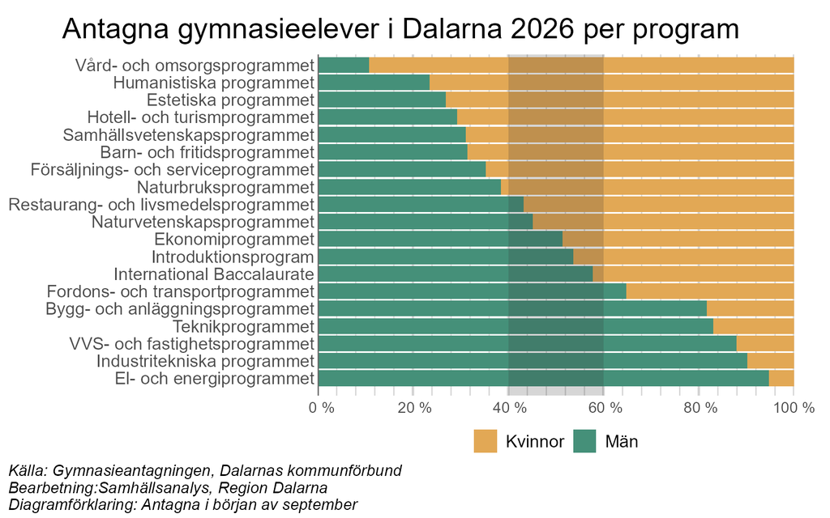

I diagrammet nedan visas genomströmningen i gymnasieskolan genom andelen med studiebevis alternativt examen 4 år efter påbörjat gymnasium. Tidigare var det generella mönstret att cirka 80 procent av tjejerna klarat av gymnasiet inom 4 år och andelen bland pojkarna något lägre, runt 75 procent. Under pandemiåren 2020 och 2021 försämrades genomströmningen, men därefter har andelen med studiebevis ökat för båda könen, men extra mycket för killarna. År 2025 var andelen med studiebevis ungefär 80 procent bland tjejer och 79 procent bland killar.

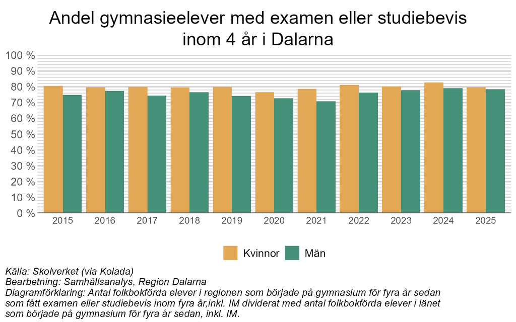